# Appendices for ‘An individual-based model of ectotherm movement integrating metabolic and microclimatic constraints’

# Appendix 1

Netlogo IBM decision making model (.nlogo). Available on [**Github**](https://github.com/darwinanddavis/Sleepy_IBM/blob/master/Sleepy%20IBM_v.6.1.1_two%20strategies.nlogo).

### space and time scales

```
; Spatial scale: 1500 * 1500 m
; 1 patch = 2 m
; 1 tick = 2 min
; 1 day = 720 ticks
; 1 tick = 2 bites possible for small food; 4 bites possible for large food
```

### interface

```
; Energy cost of individual
; =========================
; Movement-cost:    Cost (J) of moving one patch (2 m). Calculated from DEB model.
; Maintenance-cost: Cost (J) of paying maintenance. Calculated from DEB model.

; Energy gain of individual
; =================
; Low-food gain:  Energy gain (J) from small food items (Brown 1991).
; kap_X:          Conversion efficiency of assimilated energy from food (J) (Kooijman 2010).

; Food patch growth
; =================
; Large-food-initial: Initial energy level (J) of large food items at setup. Parameterised from literature.
; Small-food-initial: Initial energy level (J) of small food items at setup. Parameterised from literature.

; Individual attributes
; ===================
; Maximum-reserve: Maximum reserve level (J). Appears in 'to setup' and 'to make decision'.
; Minimum-reserve: Define the critical starvation period. Individuals can survive without food for two hours in this state (reasonable estimate).
```

### globals

```
globals
[
  in-shade?          ; Reports TRUE if turtle is in shade
  in-food?           ; Reports TRUE if turtle is in a food patch
  min-energy         ; Minimum food unit level for individual to lose interest and move away from patch. This eliminates the incentive for individuals to return immediately to the previously visited food patch after vacating it.
  reserve-level      ; Reserve level of individual.
  min-vision         ; Minimum (normal) vision range of individuals (Auburn et al. 2009).
  max-vision         ; Maximum vision range of individuals activated by starvation mode. See 'to starving' procedure (Auburn et al. 2009)
  ctmincount         ; Counter for time spent under min_T_b_
  feedcount          ; Counter for time spent in feeding state.
  restcount          ; Counter for the time spent resting in shade
  searchcount        ; Counter for time spent searching for food.
  starvecount        ; Counter for time spent in starvation state.
  shadecount         ; Counter for time spent searching for shade following a feeding bout.
  transcount         ; Counter for frequency of transitions between any of the three activity states--searching, feeding, resting.
  zenith             ; Zenith angle of sun (update-sun procedure).
  tempXY             ; XY coords for drawing homerange
  gutfull            ; Reports gut level of DEB model
  movelist           ; List of cumulative movement costs
  fh_                 ; String for working dir to export results
  ]
```

### turtles-own

```
turtles-own
[
  activity-state     ; Individual is either under a Searching, Feeding, or Resting state for each tick. The transition between the various activity states defines the global behavioural repertoire.
  energy-gain        ; Converted energy gained from food
  T_b_               ; Body temperature (T_b) of individual (Celsius)
  T_b_basking_       ; Basking body temperature of individual (Celsius)
  T_opt_range        ; Foraging body temperature range of individual (Celsius)
  T_opt              ; Median foraging body temperature of individual (Celsius)
  T_opt_lower_        ; Lower foraging body temperature of individual (Celsius)
  T_opt_upper_        ; Upper foraging body temperature of individual (Celsius)
  min-T_b_           ; Lower critical body temperature (min-T_b) of individual (Celsius)
  max-T_b_           ; Upper critical body temperature (max-T_b) of individual (Celsius)
  vision-range       ; Vision (no. of patches) range of individual.
  has-been-starving? ; Results reporter only variable for reporting stavation time only if individual has starved
  has-been-feeding?  ; Results reporter only variable for reporting feeding time only if individual has been feeding
  X                  ; List of x coords for homerange
  Y                  ; List of y coords for homerange
  gutthresh_         ; Threshold for gutlevel to motivate turtle to move
  V_pres_            ; DEB structural volume
  wetgonad_          ; DEB wet mass reproductive organ volume
  wetstorage_        ; DEB wet mass storage
  wetfood_           ; DEB converted food mass
  ]
```

### patches-own

```
patches-own
[
  patch-type    ; Defines type of patches in environment as either Food or Shade.
  food-level    ; *> Interface <* Defines the initial and updated level of energy (J) in food patches. Food level increases (plant growth; see 'Food patch growth' in Interface) and decreases (feeding by individual) with each tick.
  shade-level   ; *> Interface <* Defines the initial and updated level of shade in shade patches. Shade levels remain constant throughout simulation.
  ]
```

### breeds

```
breed
[homeranges homerange]
```

### setup

```
to setup
  ca
  if Food-patches + Shade-patches > count patches
  [ user-message (word "Lower the sum of shade and food patches to < " count patches ".")
    stop ]
  random-seed 1                          ; Outcomment to generate seed for spatial configuration of all patches in the landscape (food and shade). For reproducibility. NB: turtle movement is still stochastic. See below random-seed primitive for complete function.
  set min-energy Small-food-initial
  set min-vision 5                         ; 10m (Auburn et al. 2009)

  ask patches
  [set patch-type "Sun"
    set pcolor (random 1 + blue)]

  let NumFoodPatches Food-patches / 10
  ask n-of NumFoodPatches patches [
    ask n-of 10 patches in-radius 4 [ ; Sets 10 random food patches within a 5-patch radius of Food-patches
    let food-amount random 100
    ifelse food-amount < 50
    [set food-level (Small-food-initial) + random-float 1 * 10 ^ -5] ; Makes only one food patch attractive to turtle because turtles love good chow
    [set food-level (Large-food-initial) + random-float 1 * 10 ^ -5]
      set pcolor PatchColor
      set patch-type "Food"
      ]
  ]

ifelse Shade-density = "Random"[ ; chooser for setting Random or Clumped shade patches (similar to food patch arrangement)
  let NumShadePatches Shade-patches
  ask n-of NumShadePatches patches [
    let shade-amount random 100
    ifelse shade-amount < 50
    [set shade-level (Low-shade + random-float 1 * 10 ^ -5) ; Makes only one shade patch attractive to turtle
      set pcolor black + 2]
    [set shade-level (High-shade + random-float 1 * 10 ^ -5)
      set pcolor black]
      set patch-type "Shade"
      ]
]
[
    let NumShadePatches Shade-patches / 10
    ask n-of NumShadePatches patches [
```

[output cut: 39 more lines]

```
    if [patch-type] of patch-here = "Shade"
    [set in-shade? TRUE]
     if [patch-type] of patch-here = "Food"
    [set in-food? TRUE]
    set shape "lizard"
    set size 2
    set color red
    pen-down
    set X (list xcor)
    set Y (list ycor)
    ]
setup-spatial-plot
set fh_ fh
reset-ticks
end
```

### go

```
to go
  tick
  if not any? turtles
  [
    get-homerange
    print "All turtles dead. Check output of model results."
    repeat 3 [beep wait 0.2]
    stop
    save-world
    ]
  if (ticks * 2 / 60 / 24) = No.-of-days
  [
    ask turtle 0
    [report-results]
    stop
    save-world
    ]
  ifelse show-plots?
  []
  [clear-all-plots]
  ask turtle 0
  [
    report-patch-type
    ask turtles with [reserve-level > Minimum-reserve]
    [set vision-range min-vision]
    update-T_b
    make-decision
    set X lput xcor X ; populate X list with turtle X coords to generate home range
    set Y lput ycor Y ; populate Y list with turtle Y coords to generate home range
  ]
  if any? turtles with [reserve-level <= 0]
  [ask turtle 0 [report-results]
    stop
    ]
  ask patches with [patch-type = "Food"]
    [update-food-levels]
end
```

### update *T<sub>b</sub>*

```
to update-T_b
  ask turtles with [T_b >= max-T_b]
    [stop]
  if T_b <= min-T_b
    [set ctmincount ctmincount + 1]
    if (ctmincount * 2 / 60) = ctminthresh
    [stop]
end
```

### make-decision

```
to make-decision

;-------------------------------------------------------------------------------------
;-------------------------------------Optimising-------------------------------------
;-------------------------------------------------------------------------------------
  ifelse (strategy = "Optimising")
  [; start optimising loop
    ifelse (T_b > T_opt_upper) or (T_b < T_opt_lower)
  [
    ask turtle 0
    [;set label "Resting"
      set activity-state "R"
        if [patch-type] of patch-here != "Shade"
      [shade-search]
      if ([patch-type] of patch-here = "Shade") and (T_b < T_b_basking_)
      [set in-shade? TRUE]
      ]
    if (activity-state = "R") and (T_b >= T_b_basking_) and (T_b < T_opt_upper) ; Basking behaviour
    [set in-shade? FALSE
 ;      set transcount transcount + 1 ; Outcomment to include basking behaviour as activity state
 ;      plotxy xcor ycor
    ]
 set restcount restcount + 1
    ]
     [; else optimising loop
        if (activity-state = "R")
    [
        set restcount restcount + 1
       ; set label "Resting"
      if ((T_b <= T_opt_upper) and (T_b >= T_opt_lower)); and reserve-level < search-energy
      [set transcount transcount + 1
        plotxy xcor ycor
        set activity-state "S"]
     ; [set activity-state "R"]
    ]


    if (activity-state = "F");
    [
      ifelse (gutfull < gutthresh) ;and ([patch-type] of patch-here = "Food") ; if gut is not full, keep feeding
```

[output cut: 103 more lines]

```
    if (activity-state = "S")
    [
      ask turtle 0
      [search
       ; set label "Searching for food"
       ]
      set searchcount searchcount + 1
      if ([patch-type] of patch-here = "Food")  ;and ([food-level] of patch-here > min-energy)
      [set transcount transcount + 1
        plotxy xcor ycor
        set activity-state "F"]
      ]
    ]
  ]; end satisficing loop
end
```

### search

```
to search
  set reserve-level reserve-level - Movement-cost
  set movelist lput Movement-cost movelist
  bounce
  let local-food-patches patches with [(distance myself < [vision-range] of turtle 0) and (patch-type = "Food")]
  ifelse any? local-food-patches
  [let my-food-patch local-food-patches with-min [distance myself] ;with-max [food-level]
  face one-of my-food-patch]
  [lt random 180 - 90 ]
  fd 1
  if [patch-type] of patch-here = "Food"
  [set activity-state "F"]
end
```

### bounce

```
to bounce
; Turtles turn a random angle ~180 when encountering a wall
  ask turtle 0
 [ if abs pxcor = abs max-pxcor or
      abs pycor = abs max-pycor
    [lt random-float 180 ]
 ]
end
```

### handle food

```
to handle-food
  set energy-gain Low-food-gain
  ;set in-food? TRUE
  set feedcount feedcount + 1
  set-current-plot "Spatial coordinates of transition between activity states"
  set-current-plot-pen "Feeding"
  ifelse [pcolor] of patch-here = 45
  [set-plot-pen-color 45]
  [set-plot-pen-color 55]
  plotxy xcor ycor
end
```

### shade search

```
to shade-search
  set reserve-level reserve-level - Movement-cost ; add miniscule movement cost to avoid turtle exiting green food patches for one time step when feeding
  set movelist lput Movement-cost movelist
  let local-shade-patches patches with [(distance myself < [vision-range] of turtle 0) and (patch-type = "Shade")]
  ifelse any? local-shade-patches
  [let my-shade-patch local-shade-patches with-min [distance myself] with-max [shade-level]
    face one-of my-shade-patch
    set shadecount shadecount + 1]
  [lt random 180 - 90]
  fd 1
end
```

### rest

```
to rest
  ifelse strategy = "Optimising"
  [set activity-state "S"]
  [set activity-state "R"]
end
```

### socialise

```
to socialise
  set reserve-level reserve-level - Movement-cost ; add miniscule movement cost to avoid turtle exiting green food patches for one time step when feeding
  set movelist lput Movement-cost movelist
  bounce
  lt random 180 - 90
  fd 1
  if gutfull < gutthresh
  [set activity-state "S"]
end
```

### update food levels

```
to update-food-levels
  let food-deplete food-level - Low-food-gain
  if (count turtles-here with [activity-state = "F"] > 0) and (gutfull < gutthresh)
; [ifelse food-level < Large-food-initial
  [set food-level food-deplete ; yellow food
    set in-food? TRUE
    print "In food"]
;  [set food-level food-level - (Low-food-gain * 2)] ; green food
;  ]
  if food-level < Small-food-initial
    [set patch-type "Sun"]
set pcolor PatchColor
end
```

### report patch color

```
to-report PatchColor
  let PatColor 0
  ifelse food-level >= Large-food-initial
  [set PatColor green]
  [ifelse food-level >= Small-food-initial
    [set PatColor yellow]
    [set PatColor brown]
  ]
  report PatColor
end
```

### report patch type

```
to report-patch-type
ifelse [patch-type] of patch-here = "Food"
    [set in-food? TRUE]
    [
      ifelse [patch-type] of patch-here = "Shade"
      [set in-shade? TRUE]
      [set in-shade? FALSE
        set in-food? FALSE]
    ]
end
```

### report results

```
to report-results
    output-print (word "Number of real days:,, " precision (ticks * 2 / 60 / 24) 5)
    output-print ""
    output-print (word "Time spent searching for food (mins/days):, " (searchcount * 2) " , " precision (searchcount * 2 / 60 / 24) 3 "")
    output-print ""
    output-print (word "Time spent feeding (mins/days):, " (feedcount * 2) " , " precision (feedcount * 2 / 60 / 24) 3 "")
    output-print ""
    output-print (word "Time spent searching for shade  (mins/days):, " (shadecount * 2) " , " precision (shadecount * 2 / 60 / 24) 3 "")
    output-print ""
    output-print (word "Time spent resting in shade (mins/days):, " (restcount * 2) " , " precision (restcount * 2 / 60 / 24) 3 "")
    output-print ""
    output-print (word "Time spent in critical starvation (mins/days):, " (starvecount * 2) " , " precision (starvecount * 2 / 60 / 24) 3 "")
    output-print ""
    output-print (word "Number of transitions between activity states:, " transcount)
    output-print ""
    ifelse has-been-feeding? = TRUE
    [output-print (word "Proportion of feeding to searching:, " precision (feedcount / searchcount) 3)]
    [output-print (word "Proportion of feeding to searching:, " 0)]
    output-print ""
    ifelse has-been-starving? = TRUE
    [output-print (word "Proportion of feeding to starving:, " precision (feedcount / starvecount) 3)]
    [output-print (word "Proportion of feeding to starving:, " 0)]
    output-print ""
    output-print (word "Patches with pcolor = brown (eaten): " patches with [pcolor = 35])
    stop;die
end
```

### to save world

```
to save-world ; This procedure saves the model world. The file output procedure then outputs the saved model world as a .txt file to the local dir.
  let world user-new-file
  if ( world != false )
  [
    file-write world
    ask patches
    [
      file-write pxcor
      file-write pycor
       if patch-type = "Food"
       [file-write pxcor and pycor and (patch-type = "Food") and food-level]
       if patch-type = "Shade"
       [file-write pxcor and pycor and (patch-type = "Shade") and shade-level]
    ]
    file-close
  ]
end
```

### spatial plot

```
to setup-spatial-plot
  set-current-plot "Spatial coordinates of transition between activity states"
  set-plot-x-range min-pxcor max-pxcor
  set-plot-y-range min-pycor max-pycor
  clear-plot
end
```

### get home range

```
to get-homerange
draw-homerange
end
```

### draw home range

```
to draw-homerange
  clear-drawing
  if any? turtles [
    ask turtle 0
  [pu
   hatch-homeranges 1
   [hide-turtle
 ;  set ID [ID] of myself
     set color red
     ]
   ; draw the homerange
   foreach tempXY
   [ask homeranges
     [move-to patch (item 0 ?) (item 1 ?)
       pd
       ]
     ]
   ; close the homerange polygon
   ask homeranges
   [let lastpoint first tempXY
     move-to patch (item 0 lastpoint) (item 1 lastpoint)
     ]
   ]
 ]
end
```

# Appendix 2

Energy and heat budget models, including microclimate model (.R). Available on [**Github**](https://github.com/darwinanddavis/MalishevBullKearney).

### Initial setup

```r
# RNL_new trans model_with DEB_1.6.2

# ---------------------------------------------------------------------------
# ------------------- initial Mac OS and R config ---------------------------
# ---------------------------------------------------------------------------
# if already loaded, uninstall RNetlogo and rJava
p<-c("rJava", "RNetLogo")
remove.packages(p)

# if using Mac OSX El Capitan+ and not already in JQR, download and open JGR

# for a rJava error, run the following in terminal (src: https://stackoverflow.com/questions/30738974/rjava-load-error-in-rstudio-r-after-upgrading-to-osx-yosemite)
# sudo ln -s $(/usr/libexec/java_home)/jre/lib/server/libjvm.dylib /usr/local/lib
# then install rJava from source
install.packages("rJava", repos = "https://cran.r-project.org/", type="source")
library(rJava)

# load JGR after downloading
Sys.setenv(NOAWT=1)
install.packages("JGR")
library(JGR)
Sys.unsetenv("NOAWT")
JGR() # open JGR

# ------------------------- JGR onwards ----------------------------
# install RNetlogo from source if haven't already
install.packages("RNetLogo", repos = "https://cran.r-project.org/", type="source")
```

#### For PC and working Mac OSX

Source `DEB.R` and `onelump_varenv.R` from **Github**

```r
# ------------------- for PC and working Mac OSX ---------------------------
# ------------------- model setup ---------------------------
# get packages
packages <- c("NicheMapR","adehabitatHR","rgeos","sp", "maptools", "raster","rworldmap","rgdal","dplyr")
install.packages(packages,dependencies = T)
lapply(packages,library,character.only=T)

#source DEB and heat budget models from https://github.com/darwinanddavis/MalishevBullKearney
source('DEB.R')
source('onelump_varenv.R')

# set dirs
setwd("<your working dir>") # set wd
results.path<- "<dir path to store result outputs>" # set results path
```

### Read in microclimate data

Source `metout`, `soil`, `shadmet`, and `shadsoil` from **Github**

```r
# read in microclimate data (metout, soil, shadmet, and shadsoil)
tzone<-paste("Etc/GMT-",10,sep="")
metout<-read.csv('metout.csv')
soil<-read.csv('soil.csv')
shadmet<-read.csv('shadmet.csv')
shadsoil<-read.csv('shadsoil.csv')
micro_sun_all<-cbind(metout[,2:5],metout[,9],soil[,6],metout[,14:16])
colnames(micro_sun_all)<-c('dates','JULDAY','TIME','TALOC','VLOC','TS','ZEN','SOLR','TSKYC')
micro_shd_all<-cbind(shadmet[,2:5],shadmet[,9],shadsoil[,6],shadmet[,14:16])
colnames(micro_shd_all)<-c('dates','JULDAY','TIME','TALOC','VLOC','TS','ZEN','SOLR','TSKYC')

# choose a day(s) to simulate
daystart<-paste('09/09/05',sep="") # yy/mm/dd
dayfin<-paste('10/12/31',sep="") # yy/mm/dd
micro_sun<-subset(micro_sun_all, format(as.POSIXlt(micro_sun_all$dates), "%y/%m/%d")>=daystart & format(as.POSIXlt(micro_sun_all$dates), "%y/%m/%d")<=dayfin)
micro_shd<-subset(micro_shd_all, format(as.POSIXlt(micro_shd_all$dates), "%y/%m/%d")>=daystart & format(as.POSIXlt(micro_shd_all$dates), "%y/%m/%d")<=dayfin)
days<-as.numeric(as.POSIXlt(dayfin)-as.POSIXlt(daystart))

# create time vectors
time<-seq(0,(days+1)*60*24,60) #60 minute intervals from microclimate output
time<-time[-1]
times2<-seq(0,(days+1)*60*24,2) #two minute intervals for prediction
time<-time*60 # minutes to seconds
times2<-times2*60 # minutes to seconds

# apply interpolation functions
velfun<- approxfun(time, micro_sun[,5], rule = 2)
Zenfun<- approxfun(time, micro_sun[,7], rule = 2)
Qsolfun_sun<- approxfun(time, micro_sun[,8], rule = 2)
Tradfun_sun<- approxfun(time, rowMeans(cbind(micro_sun[,6],micro_sun[,9])), rule = 2)
Tairfun_sun<- approxfun(time, micro_sun[,4], rule = 2)
Qsolfun_shd<- approxfun(time, micro_shd[,8]*.1, rule = 2)
Tradfun_shd<- approxfun(time, rowMeans(cbind(micro_shd[,6],micro_shd[,9])), rule = 2)
Tairfun_shd<- approxfun(time, micro_shd[,4], rule = 2)

# upper and lower activity thermal limits
VTMIN<- 26
VTMAX<- 35
```

### Read in DEB parameters

Source `DEB_pars_Tiliqua_rugosa.csv` from **Github**

```r
# *************************** read in DEB parameters ***************************

debpars=as.data.frame(read.csv('DEB_pars_Tiliqua_rugosa.csv',header=FALSE))$V1 # read in DEB pars

# set core parameters
z=debpars[8] # zoom factor (cm)
F_m = 13290 # max spec searching rate (l/h.cm^2)
kap_X=debpars[11] # digestion efficiency of food to reserve (-)
v=debpars[13] # energy conductance (cm/h)
kap=debpars[14] # kappa, fraction of mobilised reserve to growth/maintenance (-)
kap_R=debpars[15] # reproduction efficiency (-)
p_M=debpars[16] # specific somatic maintenance (J/cm3)
k_J=debpars[18] # maturity maint rate coefficient (1/h)
E_G=debpars[19] # specific cost for growth (J/cm3)
E_Hb=debpars[20] # maturity at birth (J)
E_Hp=debpars[21] # maturity at puberty (J)
h_a=debpars[22]*10^-1 # Weibull aging acceleration (1/h^2)
s_G=debpars[23] # Gompertz stress coefficient (-)

# set thermal respose curve paramters
T_REF = debpars[1]-273
TA = debpars[2] # Arrhenius temperature (K)
TAL = debpars[5] # low Arrhenius temperature (K)
TAH = debpars[6] # high Arrhenius temperature (K)
TL = debpars[3] # low temp boundary (K)
TH = debpars[4] # hight temp boundary (K)

# set auxiliary parameters
del_M=debpars[9] # shape coefficient (-)
E_0=debpars[24] # energy of an egg (J)
mh = 1 # survivorship of hatchling in first year
mu_E = 585000 # molar Gibbs energy (chemical potential) of reserve (J/mol)
E_sm=186.03*6
gutfull <- 1
# set initial state
E_pres_init = (debpars[16]*debpars[8]/debpars[14])/(debpars[13]) # initial reserve
E_m <- E_pres_init
E_H_init = debpars[21] + 5

#### change inital size here by multiplying by < 0.85 ####
V_pres_init = (debpars[26] ^ 3) * 0.85
d_V<-0.3
mass <- V_pres_init + V_pres_init*E_pres_init/mu_E/d_V*23.9

# ***************** end TRANSIENT MODEL SETUP ***************
# ***********************************************************
```

### Initialise decision-making and DEB models

Source Netlogo model from **Github**

```r
# ********************** start NETLOGO SIMULATION  ***********************

nl.path<- "<dir path to Netlogo program>"
ver <-"<version number of Netlogo>" # type in version of Netlogo e.g. "6.0.1"
# if error, try adding "/app" to end of dir path for running in Windows and El Capitan for OSX
# nl.path<-"<dir path to Netlogo program>/app"
NLStart(nl.path)
NLStart(nl.path, nl.jarname = paste0("netlogo-",ver,".jar"))
model.path<- "<dir path to Netlogo model>"
NLLoadModel(model.path)

# ************************ setup NETLOGO MODEL *************************

# 1. update animal and env traits
month<-"sep"
NL_days<-117       # No. of days simulated
NL_gutthresh<-0.75
gutfull<-0.8

# set resource density
if(density=="high"){
    NL_shade<-100000L       # Shade patches
    NL_food<-100000L         # Food patches
    }else{
    NL_shade<-1000L     # Shade patches
    NL_food<-1000L  # Food patches
}

# 2. update initial conditions for DEB model
Es_pres_init<-(E_sm*gutfull)*V_pres_init
acthr<-1
Tb_init<-20
step = 1/24
debout<-DEB(step = step, z = z, del_M = del_M, F_m = F_m *
    step, kap_X = kap_X, v = v * step, kap = kap, p_M = p_M *
    step, E_G = E_G, kap_R = kap_R, k_J = k_J * step, E_Hb = E_Hb,
    E_Hj = E_Hb, E_Hp = E_Hp, h_a = h_a/(step^2), s_G = s_G,
    T_REF = T_REF, TA = TA, TAL = TAL, TAH = TAH, TL = TL,
    TH = TH, E_0 = E_0, E_pres=E_pres_init, V_pres=V_pres_init, E_H_pres=E_H_init, acthr = acthr, breeding = 1, Es_pres = Es_pres_init, E_sm = E_sm)

# 3. calc direct movement cost
V_pres<-debout[2]
step<-1/24 #hourly

p_M2<-p_M*step #J/h
p_M2<-p_M2*V_pres # loco cost * structure
names(p_M2)<-NULL # remove V_pres name attribute from p_M

# movement cost for time period
VO2<-0.45 # O2/g/h JohnAdler etal 1986

# multiple p_M by structure = movement cost (diff between p_M with loco cost and structure for movement period)
# p_M with loco cost
loco<-VO2*mass*20.1 # convert ml O2 to J = J/h
loco<-loco+p_M2 # add to p_M = J/h
loco<-loco/30/V_pres ; loco #J/cm3/2min

Es_pres_init<-(E_sm*gutfull)*V_pres_init
X_food<-3000
V_pres<-debout[2]
wetgonad<-debout[19]
wetstorage<-debout[20]
wetfood<-debout[21]
ctminthresh<-120000
Tairfun<-Tairfun_shd
Tc_init<-Tairfun(1)+0.1 # Initial core temperature

NL_T_b<-Tc_init       # Initial T_b
NL_T_b_min<-VTMIN         # Min foraging T_b
NL_T_b_max<-VTMAX        # Max foraging T_b
NL_ctminthresh<-ctminthresh # No. of consecutive hours below CTmin that leads to death
NL_reserve<-E_m        # Initial reserve density
NL_max_reserve<-E_m    # Maximum reserve level
NL_maint<-round(p_M, 3)               # Maintenance cost
NL_move<-round(loco, 3)               # Movement cost
NL_zen<-Zenfun(1*60*60)     # Zenith angle

strategy<-function(strategy){ # set movement strategy
  if (strategy == "O"){
    NLCommand("set strategy \"Optimising\" ")
    }else{
    NLCommand("set strategy \"Satisficing\" ")
    }
  }
strategy("O") # "S"

shadedens<-function(shadedens){ # set movement strategy
  if (shadedens == "Random"){
    NLCommand("set Shade-density \"Random\" ")
    }else{
    NLCommand("set Shade-density \"Clumped\" ")
    }
  }
shadedens("Clumped") # set clumped resources
```

### Run simulation

```r
sc<-1 # set no. of desired simualations---for automating writing of each sim results to file. N = N runs
for (i in 1:sc){ # start sc sim loop

NLCommand("set Shade-patches",NL_shade,"set Food-patches",NL_food,"set No.-of-days",NL_days,"set T_b precision",
NL_T_b, "2","set T_opt_lower precision", NL_T_b_min, "2","set T_opt_upper precision", NL_T_b_max, "2",
"set reserve-level", NL_reserve, "set Maximum-reserve", NL_max_reserve, "set Maintenance-cost", NL_maint,
"set Movement-cost precision", NL_move, "3", "set zenith", NL_zen, "set ctminthresh", NL_ctminthresh,
"set gutthresh", NL_gutthresh, 'set gutfull', gutfull, 'set V_pres precision', V_pres, "5", 'set wetstorage precision', wetstorage, "5",
'set wetfood precision', wetfood, "5", 'set wetgonad precision', wetgonad, "5","setup")

#NLCommand("inspect turtle 0")

NL_ticks<-NL_days / (2 / 60 / 24) # No. of NL ticks (measurement of days)
NL_T_opt_l<-NLReport("[T_opt_lower] of turtle 0")
NL_T_opt_u<-NLReport("[T_opt_upper] of turtle 0")

# data frame setup for homerange polygon
turtles<-data.frame() # make an empty data frame
NLReport("[X] of turtle 0"); NLReport("[Y] of turtle 0")
who<-NLReport("[who] of turtle 0")

# ************************************************************************
# ******************** start NETLOGO SIMULATION  *************************

debcall<-0 # check for first call to DEB
stepcount<-0 # DEB model step count

for (i in 1:NL_ticks){
stepcount<-stepcount+1
NLDoCommand(1, "go")

######### Reporting presence of shade
shade<-NLGetAgentSet("in-shade?","turtles", as.data.frame=T); shade<-as.numeric(shade) # returns an agentset of whether turtle is currently on shade patch

# choose sun or shade
tick<-i
times3<-c(times2[tick],times2[tick+1])

if(shade==0){
  Qsolfun<-Qsolfun_sun
  Tradfun<-Tradfun_sun
  Tairfun<-Tairfun_sun
}else{
  Qsolfun<-Qsolfun_shd
  Tradfun<-Tradfun_shd
  Tairfun<-Tairfun_shd
}
if(i==1){
Tc_init<-Tairfun(1)+0.1 #initial core temperature
}

# one_lump_trans params
Qsol<-Qsolfun(mean(times3)); Qsol
vel<-velfun(mean(times3)) ;vel
Tair<-Tairfun(mean(times3));Tair
Trad<-Tradfun(mean(times3)); Trad
Zen<-Zenfun(mean(times3)); Zen

# calc Tb params at 2 mins interval
Tbs<-onelump_varenv(t=120,time=times3[2],Tc_init=Tc_init,thresh = 30, AMASS = mass, lometry = 3, Tairf=Tairfun,Tradf=Tradfun,velf=velfun,Qsolf=Qsolfun,Zenf=Zenfun)
Tb<-Tbs$Tc
rate<-Tbs$dTc
Tc_init<-Tb

NLCommand("set T_b precision", Tb, "2") # Updating Tb
NLCommand("set zenith", Zenfun(times3[2])) # Updating zenith

# time spent below VTMIN
ctminhours<-NLReport("[ctmincount] of turtle 0") * 2/60 # ticks to hours
if (ctminhours == NL_ctminthresh) {NLCommand("ask turtle 0 [stop]")}

# ******************** start DEB SIMULATION  ****************************

if(stepcount==1) { # run DEB loop every time step (2 mins)
stepcount<-0

# report activity state
actstate<-NLReport("[activity-state] of turtle 0")
 # Reports true if turtle is in food
actfeed<-NLGetAgentSet("in-food?","turtles", as.data.frame=T); actfeed<-as.numeric(actfeed)

n<-1 # time steps
step<-2/1440 # step size (2 mins). For hourly: 1/24
# update direct movement cost
if(actstate == "S"){
    NLCommand("set Movement-cost", NL_move)
    }else{
        NLCommand("set Movement-cost", 1e-09)
        }
# if within activity range, it's daytime, and gut below threshold
if(Tbs$Tc>=VTMIN & Tbs$Tc<=VTMAX & Zen!=90 & gutfull<=NL_gutthresh){
  acthr=1 # activity state = 1
if(actfeed==1){ # if in food patch
    X_food<-NLReport("[energy-gain] of turtle 0") # report joules intake
    }
    }else{
        X_food = 0
        acthr=0
        }

# calculate DEB output
if(debcall==0){
    # initialise DEB
    debout<-matrix(data = 0, nrow = n, ncol = 26)
    deb.names<-c("E_pres","V_pres","E_H_pres","q_pres","hs_pres","surviv_pres","Es_pres","cumrepro","cumbatch","p_B_past","O2FLUX","CO2FLUX","MLO2","GH2OMET","DEBQMET","DRYFOOD","FAECES","NWASTE","wetgonad","wetstorage","wetfood","wetmass","gutfreemass","gutfull","fecundity","clutches")
    colnames(debout)<-deb.names
    # initial conditions
    debout<-DEB(E_pres=E_pres_init, V_pres=V_pres_init, E_H_pres=E_H_init, acthr = acthr, Tb = Tb_init, breeding = 1, Es_pres = Es_pres_init, E_sm = E_sm, step = step, z, del_M = del_M, F_m = F_m *
    step, kap_X = kap_X, v = v * step, kap = kap, p_M = p_M *
    step, E_G = E_G, kap_R = kap_R, k_J = k_J * step, E_Hb = E_Hb,
    E_Hj = E_Hb, E_Hp = E_Hp, h_a = h_a/(step^2), s_G = s_G,
    T_REF = T_REF, TA = TA, TAL = TAL, TAH = TAH, TL = TL,
    TH = TH, E_0 = E_0)
    debcall<-1
    }else{
        debout<-DEB(step = step, z = z, del_M = del_M, F_m = F_m *
    step, kap_X = kap_X, v = v * step, kap = kap, p_M = p_M *
    step, E_G = E_G, kap_R = kap_R, k_J = k_J * step, E_Hb = E_Hb,
    E_Hj = E_Hb, E_Hp = E_Hp, h_a = h_a/(step^2), s_G = s_G,
    T_REF = T_REF, TA = TA, TAL = TAL, TAH = TAH, TL = TL,
    TH = TH, E_0 = E_0,
          X=X_food,acthr = acthr, Tb = Tbs$Tc, breeding = 1, E_sm = E_sm, E_pres=debout[1],V_pres=debout[2],E_H_pres=debout[3],q_pres=debout[4],hs_pres=debout[5],surviv_pres=debout[6],Es_pres=debout[7],cumrepro=debout[8],cumbatch=debout[9],p_B_past=debout[10])
        }
mass<-debout[22]
gutfull<-debout[24]
NL_reserve<-debout[1]
V_pres<-debout[2]
wetgonad<-debout[19]
wetstorage<-debout[20]
wetfood<-debout[21]

#update NL wetmass properties
NLCommand("set V_pres precision", V_pres, "5")
NLDoCommand("plot xcor ycor")
NLCommand("set wetgonad precision", wetgonad, "5")
NLDoCommand("plot xcor ycor")
NLCommand("set wetstorage precision", wetstorage, "5")
NLDoCommand("plot xcor ycor")
NLCommand("set wetfood precision", wetfood, "5")
NLDoCommand("plot xcor ycor")


} #--- end DEB loop

NLCommand("set reserve-level", NL_reserve) # update reserve
NLCommand("set gutfull", debout[24])# update gut level

# ******************** end DEB SIMULATION *************************

# generate results, with V_pres, wetgonad, wetstorage, and wetfood from debout
if(i==1){
    results<-cbind(tick,Tb,rate,shade,V_pres,wetgonad,wetstorage,wetfood,NL_reserve)
    }else{
        results<-rbind(results,c(tick,Tb,rate,shade,V_pres,wetgonad,wetstorage,wetfood,NL_reserve))
        }
results<-as.data.frame(results)

# generate data frames for homerange polygon
if (tick == NL_ticks - 1){
    X<-NLReport("[X] of turtle 0"); head(X)
    Y<-NLReport("[Y] of turtle 0"); head(Y)
    turtles<-data.frame(X,Y)
    who1<-rep(who,NL_ticks); who # who1<-rep(who,NL_ticks - 1); who
    turtledays<-rep(1:NL_days,length.out=NL_ticks,each=720)
    turtle<-data.frame(ID = who1,days=turtledays)
    turtles<-cbind(turtles,turtle)
    }

} # ************************** end NL loop *********************************

# get hr data
spdf<-SpatialPointsDataFrame(turtles[1:2], turtles[3]) # creates a spatial points data frame (adehabitatHR package)
homerange<-mcp(spdf,percent=95)

# writing new results
if (exists("results")){  #if results exist
    sc<-sc-1
    nam <- paste("results", sc, sep = "") # generate new name with added sc count
    rass<-assign(nam,results) #assign new name to results. call 'results1, results2 ... resultsN'
    namh <- paste("turtles", sc, sep = "")  #generate new name with added sc count
    rassh<-assign(namh,turtles) #assign new name to results. call 'results1, results2 ... resultsN'
    nams <- paste("spdf", sc, sep = "")
    rasss<-assign(nams,spdf)
    namhr <- paste("homerange", sc, sep = "")
    rasshr<-assign(namhr,homerange)

    fh<-results.path; fh
    for (i in rass){
        # export all results
        write.table(results,file=paste(fh,nam,".R",sep=""))
        }
    for (i in rassh){
        # export turtle location data
        write.table(turtles,file=paste(fh,namh,".R",sep=""))
        }
        #export NL plots
        month<-"sep"
        #spatial plot
        sfh<-paste(month,NL_days,round(mass,0),NL_shade,as.integer(NL_food*10),"_",sc,"_move","",sep="");sfh
        NLCommand(paste("export-plot \"Spatial coordinates of transition between activity states\" \"",results.path,sfh,".csv\"",sep=""))
        #temp plot
        tfh<-paste(month,NL_days,round(mass,0),NL_shade,as.integer(NL_food*10),"_",sc,"_temp",sep="")
        NLCommand(paste("export-plot \"Body temperature (T_b)\" \"",results.path,tfh,".csv\"",sep=""))
        #activity budget
        afh<-paste(month,NL_days,round(mass,0),NL_shade,as.integer(NL_food*10),"_",sc,"_act","",sep="");afh
        NLCommand(paste("export-plot \"Global time budget\" \"",results.path,afh,".csv\"",sep=""))
        #text output
        xfh<-paste(month,NL_days,round(mass,0),NL_shade,as.integer(NL_food*10),"_",sc,"_txt",sep="");xfh
        NLCommand(paste("export-output \"",results.path,xfh,".csv\"",sep=""))
        #gut level
        gfh<-paste(month,NL_days,round(mass,0),NL_shade,as.integer(NL_food*10),"_",sc,"_gut","",sep="");gfh
        NLCommand(paste("export-plot \"Gutfull\" \"",results.path,gfh,".csv\"",sep=""))
        #wet mass
        mfh<-paste(month,NL_days,round(mass,0),NL_shade,as.integer(NL_food*10),"_",sc,"_wetmass","",sep="");mfh
        NLCommand(paste("export-plot \"Total wetmass plot\" \"",results.path,mfh,".csv\"",sep=""))
        #movement cost (loco)
        lfh<-paste(month,NL_days,round(mass,0),NL_shade,as.integer(NL_food*10),"_",sc,"_loco","",sep="");lfh
        NLCommand(paste("export-plot \"Movement costs\" \"",results.path,lfh,".csv\"",sep=""))
    }
} # ********************** end sc sim loop *****************************

#*********************** end NETLOGO SIMULATION ****************************
#***************************************************************************
```

### Example of data output files from simulation

```r
# example files of results output in results.path
list.files(results.path)
# [1] "results0.R"                    "sep572310001000_0_act.csv"
# [3] "sep572310001000_0_gut.csv"     "sep572310001000_0_loco.csv"
# [5] "sep572310001000_0_move.csv"    "sep572310001000_0_temp.csv"
# [7] "sep572310001000_0_txt.csv"     "sep572310001000_0_wetmass.csv"
# [9] "turtles0.R"
```

# Appendix 3

### Summary of DEB parameters and primary metabolic pathways.

In DEB theory, flows of energy $(\dot{p})$ and mass $(\dot{J})$ from food are tracked through time to predict the individual state in terms of growth (structure, $V$, i.e. volume of body tissue built during growth and which requires maintenance), body condition (reserve, $E$, the chemical intermediary between the transformation of food and the growth and maintenance of structure), and maturity ($E_H$, the energy invested in increasing the maturation state, i.e. energetic costs of development, all of which is dissipated) (Kooijman 2010). Temperature $(T)$ influences all rates according to the Arrhenius model. Food $(X)$ is eaten $(\dot{p_X})$ then converted $(\dot{p}_A)$ to reserve, which is subsequently mobilized to fuel the rest of the metabolism. Reserve is readily available pools of generalised compounds, rather than simply energy or fat storage, contained within individual body cells and collectively, per structural volume, measured as reserve density, $[E]$. Food intake scales with food density following a functional response $f$ (Table 1), whereby either searching or handling limits individuals as $f$ increases from 0 to 1, respectively. Following an allocation rule ($\kappa$ rule), reserves are mobilised $(\kappa \dot{p}_C)$ to structure via the natural hierarchy of cell metabolism—first to somatic maintenance $(\dot{p}_M)$ then to growth $(\dot{p}_G)$. The remaining fixed fraction $((1 - \kappa)\dot{p}_C)$ of mobilised energy $(\dot{p}_R)$ then fuels maturation and reproduction. Animals switch between three maturity stages—embryo, juvenile, and adult—defined by maturity thresholds representing the cumulative energy invested in maturation. Energy is also invested in maintenance of a given level of maturity $(\dot{p}_J)$ and, once reaching puberty, excess energy beyond maturity maintenance costs is invested in reproductive biomass $(\dot{p}_R)$. See Fig. 4 in Kearney et al. (2013) for a schematic breakdown of the above processes.

In DEB theory, reserve dynamics drive metabolism. The rate of assimilated food into energy $\dot{p}_A$ follows the Holling Type II functional response $f$

$$[\dot{p}_A] = \frac
{f \dot{\{p}_{Am}\}}
{L}$$

where {$\dot{p}_{Am}$} is the maximum assimilation rate and the volumetric body length $L \equiv V^\frac{1}{3}$. Parameters surrounded by square [*] and curly {*} parentheses are per volume and surface area, respectively. Energy is then mobilised from reserves with a constant fraction going to somatic maintenance and somatic growth

$$\kappa[\dot{p}_C] = \frac
{\dot{v}[E]}
{L}
- \dot{r}[E]$$

where $\dot{v}$ is energy conductance of mobilised reserve and $\dot{r}$ is specific growth rate, i.e. change in structure $V$ over time

$$\frac
{\delta V}
{\delta t}
= V\dot{r}
= V \frac
{\frac
{[E]\dot{v}}
{L} - \frac
{[\dot {p}_M]}
{\kappa}
}
{[E] + \frac
{[E_G]}
{\kappa}
}$$

with $[\dot{p}_M]$ the somatic maintenance cost **(Eq. 5)** and $[E_G]$ the cost of producing structural tissue (both biomass and overhead costs). This relationship means growth $(\dot{r})$ dilutes reserve levels, measured as reserve density per volume $[E]$, as it rises and falls with incoming energy $[\dot{p}_A]$ minus energy used for metabolic processes $[\dot{p}_C]$, giving the reserve dynamics equation

$$\frac
{\delta [E]}
{\delta t}
= [\dot{p}_A] - [\dot{p}_C]$$

*Maintenance*  
Heat, water, and CO<sub>2</sub> are expelled as products from the costs of maintaining the volume $[\dot{p}_M]$ and surface $\dot{\{p}_T\}$ of structure

$$[\dot{p}_M]
= \left(
[\dot{p}_M] + \frac
{\dot{\{p}_T\}}
{L}
\right)$$

Further costs include the overheads of reproduction, feeding (heat increment of $f$), and growth $\dot{p}_G$, including growth overhead costs and tissue biomass

$$[\dot{p}_G] = \kappa [\dot{p}_C] - V [\dot{p}_M]$$

while maturity maintenance $\dot{p}_J$ from $(1 - \kappa)\dot{p}_C = \dot{p}_J + \dot{p}_R$, measured by energy dissipated as heat, contributes to maintaining the current and transitioning to the next maturity level

$$\dot{p}_J =
\begin{cases}
E_H \dot{k}_J, & E_H ≤ E^p_H \\
E^p_H \dot{k}_J, & E_H > E^p_H
\end{cases}$$

where $\dot{k}_J$ is a coefficient controlling the rate of maturity maintenance. The organism first pays maturity maintenance and, in an immature individual, the remaining flux feeds further increases in maturity

$$\dot{p}_R = (1 - \kappa)\dot{p}_C - \dot{p}_J$$

*Growth*  
Animals grow in structural length $L$ (~ maximum $L_m$) with $\dot{r}$ **(Eq. 3)** only after paying maintenance $\dot{p}_M$; maintaining and growing cells incurs growth costs of new biovolume, calculated as an energy investment ratio $g$

$$g = \frac
{[E_G]}
{\kappa[E_m]}$$

where $[E_m]$ is maximum reserve density $[E]$ when $f = 1$. Reserve density $[E]$ is scaled to $e$ to interpret changes in $f$ as animals encounter food at different densities over time, giving

$$\frac
{\delta e}
{\delta t}
= \frac
{\delta \frac
{[E]}
{[E_m]}
}
{\delta t}
= \frac
{\dot{v}(f - e)}
{L}$$

so under steady state, i.e. when food is constant, $f = e$. In the standard DEB model, body shape remains constant (isomorphic) during growth. Therefore, the body surface area is proportional to volume $V^\frac{2}{3}$. Following **Eq. 3** so that $\frac{\delta L}{\delta V} = \frac {L\dot{r}}{3}$ given $L \equiv V^\frac{1}{3}$, an isomorphic animal increases in body length under constant food following

$$\frac
{\delta L}
{\delta t}
= \frac
{\dot{v}}
{3} \cdot \frac
{e - \frac
{L}
{L_m}
}
{e + g}$$

# Figures

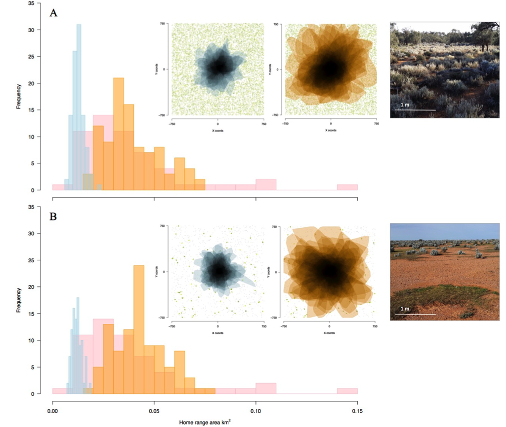

Figure S1. Distributions of home range area (km<sup>2</sup>) of real animals (pink) and simulated optimising (orange) and satisficing (blue) movement strategies under (A) dense and (B) sparse resource distribution (food and shade). Insets (L–R): Home range polygons in space showing overlap of simulated satisficing (blue) and optimising (orange) movement strategies, and examples of (upper) dense and (lower) sparse resource distributions in the study site.

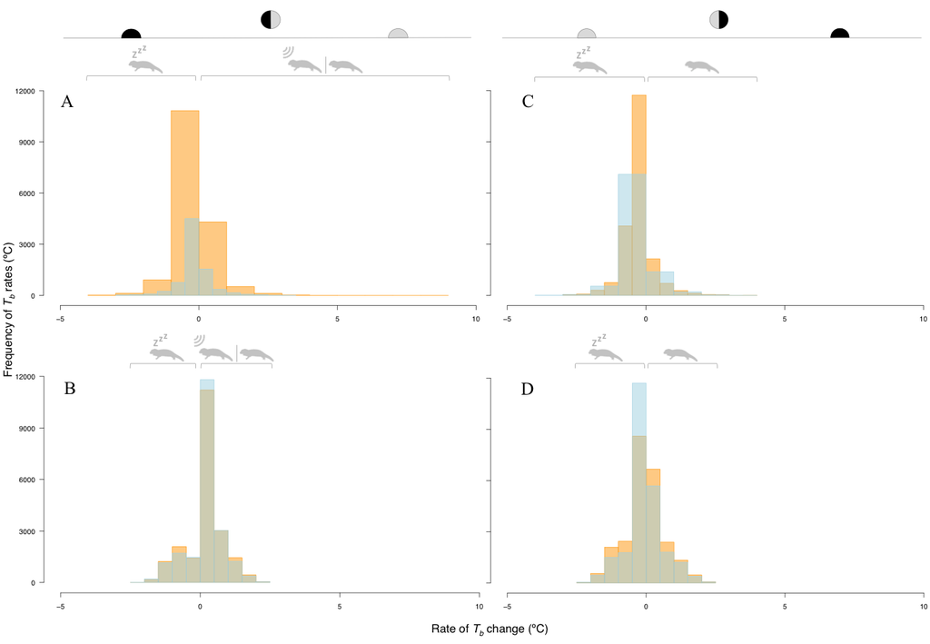

Figure S2. Rates of Tb change (ºC 2 min<sup>–1</sup>) comparing (A) observed active (orange; #11885) and passive (blue; #11533) movement and (B) simulated optimising (orange) and satisficing (blue) movement for the morning hours (heating period; 06:00–12:00). (C) Observed active (orange) and passive (blue) movement and (D) simulated optimising (orange) and satisficing (blue) movement for the afternoon hours (cooling period; 12:00–18:00) throughout the breeding season. Animal graphics represent the most probable activity state of the animal (from Fig. 2).

# References

Auburn, Z. M., Bull, C. M. and Kerr G. D. (2009) The visual perceptual range of a lizard, *Tiliqua rugosa*, Journal of Ethology, 27: 75-81.

Brown, G. W. (1991) Ecological feeding analysis of south-eastern Australian Scincids (Reptilia–Lacertilia), Australian Journal of Zoology, 39: 9-29.

Kooijman, S.A.L.M., (2010). Dynamic Energy Budget Theory, Cambridge, UK: Cambridge University Press.

Pamula, Y. (1997) Ecological and physiological aspects of reproduction in the viviparous skink *Tiliqua rugosa*, Ph.D. thesis, Flinders University, South Australia, Australia.

[^1]: ‘This Supplementary Material can be found at https://github.com/darwinanddavis/MalishevBullKearney or https://doi.org/10.5281/zenodo.998145.’